# Credit Risk Analytics

### Design a strategy to identify right customers during credit application phase

A leading credit card provider gets thousands of credit card applicants every year. But in the past few years, it has experienced an increase in credit loss.The CEO believes that the best strategy to mitigate credit risk is to 'acquire the right customers'.

We will use socio-demographic data provided by applicants during the credit application phase like age, gender, income, marital status, etc and credit bureau data to determine the factors affecting credit risk, create strategies to mitigate the acquisition risk and assess the financial benefit derived from the project.

The idea is to develope a predictive model to predict the likelihood of credit default by the applicants. We will identify the potential defaulters during application phase so that such customers are rejected and right customers are provided the credit card. This in turn will minimise the credit loss.

The standard process followed in analytics projects is:

1. Business Understanding
2. Data Understanding
3. Model Development
4. Model Evaluation
5. Recommendations

### Business Understanding

The objective is to identify right customers during credit application phase so that credit facility to the potential bad customers can be avoided and credit loss can be minimised.

### Data Understanding

The data files provided by CredX are 1. Demographic data.csv 2. Credit Bureau data.csv

```r
Demographic_data <- read.csv("Demographic data.csv", stringsAsFactors = F)
CB_data <- read.csv("Credit Bureau data.csv", stringsAsFactors = F)
```

```r
# Replace dots in col name with underscore
colnames(Demographic_data) <- stringr::str_replace_all(colnames(Demographic_data), c("\\." = "_"))
colnames(CB_data) <- stringr::str_replace_all(colnames(CB_data), c("\\." = "_" , "\\.." = "_" ))
```

Demographic data has 71295 observations,i.e, we have 71295 applicants with 12 attributes like age, income, residence, gender, profession etc.

Credit Bureau data has 71295 observations with 19 attributes like DPD in 12 months, DPD in 6 months, outstanding balance, Average credit utilization etc.

The attribute "performance tag" represents whether the applicant has gone 90 days past due or worse in the past 12-months (i.e. defaulted) after getting a credit card.It thus contains only two values:-- 1 or 0 (1 means default and 0 means non-default) . It is called the target attribute since that is what we want to predict using the other attributes.

```r
#--Merge demographic and credit Bureau data to create master dataset
CreditData <- dplyr::inner_join(Demographic_data, CB_data, by = "Application_ID")
```

#### Data Quality, EDA and WoE

We always start with cleaning the data, i.e removing missing values, erroneous entries, treat outliers etc. Next we do EDA to get some intution about the data by analysing attributes.To identify important variables we will also calculate weight of evidence(WoE) and plot the important ones.

```r
CreditData_status <- df_status(CreditData, print_results = F) %>%
  dplyr::select(variable, type, unique, q_na) %>%
  arrange(type)

# variables with NA values
var_NA <- CreditData_status[(CreditData_status$q_na > 0),]
NA_value_pct <- CreditData %>%
 dplyr::summarise_all(funs(round(sum(is.na(.))/n()*100,2)))
NA_value_pct <- tidyr::gather(NA_value_pct,key = 'feature',value = 'missing_percent')
NA_value_pct <- NA_value_pct[,c(1, round(2,4))]
nonzero_NA_value_pct <- NA_value_pct[NA_value_pct$missing_percent > 0,]
nonzero_NA_value_pct[order(-nonzero_NA_value_pct$missing_percent),]
```

```
##                                   feature missing_percent
## 12                        Performance_Tag            2.00
## 19 Avgas_CC_Utilization_in_last_12_months            1.48
## 26             Presence_of_open_home_loan            0.38
## 27                    Outstanding_Balance            0.38
```

There are few variables with missing values among which approx 1.5% of records have missing Average credit utilization. Also approx. 2% of applications have missing performance tag. These must be rejected applications.

```r
Perf_NA <- CreditData[is.na(CreditData$Performance_Tag),]
CreditData <- CreditData[!is.na(CreditData$Performance_Tag),]
```

```r
# Attribute 1:  Income (numerical)
#-------------------------------------------------

# Data Quality
CreditData[which(CreditData$Income <= 0),]$Income <- 4.5
```

Income do not have outliers.However, there are records with income as 0 or less then 0. For such records we will replace 0 income at 5th %tile

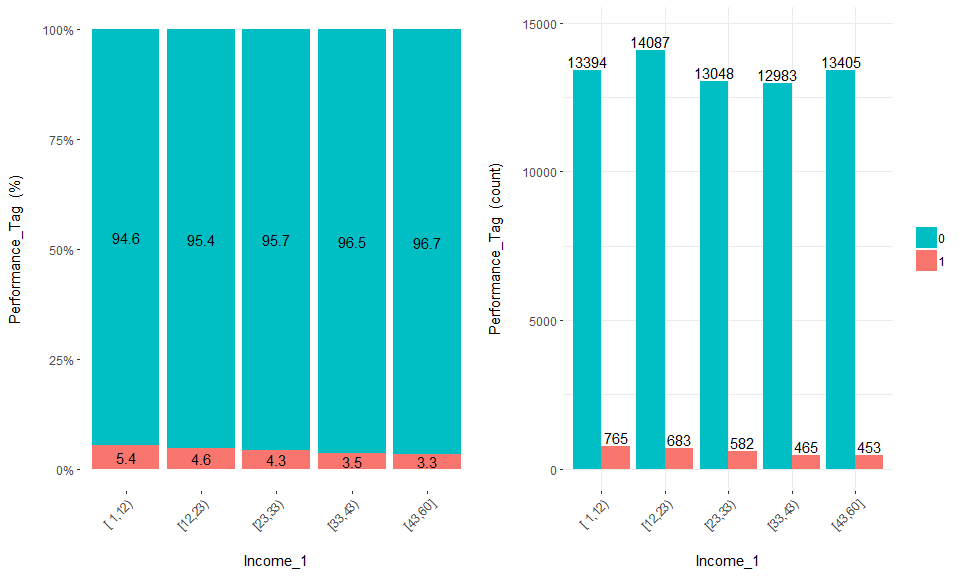

```r
# EDA
CreditData$Income_1 <- equal_freq(var = CreditData$Income, n_bins = 5)

#-- bar plot: performance ~ Income
cross_plot(CreditData,input = "Income_1", target = "Performance_Tag", auto_binning = FALSE)
```

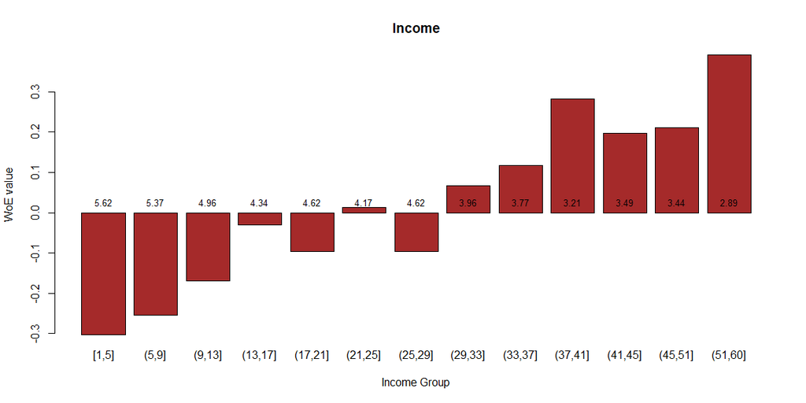

```r
#  WoE plot

BinIncome_WoE <- WOE_fn(CreditData$Income_Group, CreditData$Performance_Tag)
bp_BinIncome <- barplot(BinIncome_WoE$WoE, col = "brown", names.arg = BinIncome_WoE$Buckets,
                        main = "Income",
                        xlab = "Income Group",
                        ylab = "WoE value")
text(bp_BinIncome,0, round(BinIncome_WoE$Bad_Rate,2), cex = 0.8, pos = 3) # , srt = 90
```

```r
kable(BinIncome_WoE, caption = 'Customer Income ~ Good-Bad')
```

| Buckets | 0 | 1 | TotalObs | Distr_Good | Distr_Bad | Overall_Pct | Bad_Rate | WoE | IV | Efficiency |
| --- | --- | --- | --- | --- | --- | --- | --- | --- | --- | --- |
| [1,5] | 5973 | 356 | 6329 | 8.9260 | 12.0760 | 9.0589 | 5.6249 | -0.3023 | 0.9522 | 1.5750 |
| (5,9] | 4897 | 278 | 5175 | 7.3180 | 9.4301 | 7.4071 | 5.3720 | -0.2536 | 0.5356 | 1.0560 |
| (9,13] | 4986 | 260 | 5246 | 7.4510 | 8.8195 | 7.5088 | 4.9562 | -0.1686 | 0.2307 | 0.6842 |
| (13,17] | 5154 | 234 | 5388 | 7.7021 | 7.9376 | 7.7120 | 4.3430 | -0.0301 | 0.0071 | 0.1178 |
| (17,21] | 5176 | 251 | 5427 | 7.7350 | 8.5142 | 7.7678 | 4.6250 | -0.0960 | 0.0748 | 0.3896 |
| (21,25] | 5176 | 225 | 5401 | 7.7350 | 7.6323 | 7.7306 | 4.1659 | 0.0134 | 0.0014 | 0.0514 |
| (25,29] | 5220 | 253 | 5473 | 7.8007 | 8.5821 | 7.8337 | 4.6227 | -0.0955 | 0.0746 | 0.3907 |
| (29,33] | 5336 | 220 | 5556 | 7.9741 | 7.4627 | 7.9525 | 3.9597 | 0.0663 | 0.0339 | 0.2557 |
| (33,37] | 5210 | 204 | 5414 | 7.7858 | 6.9199 | 7.7492 | 3.7680 | 0.1179 | 0.1021 | 0.4329 |
| (37,41] | 5181 | 172 | 5353 | 7.7424 | 5.8345 | 7.6619 | 3.2132 | 0.2829 | 0.5397 | 0.9539 |
| (41,45] | 5001 | 181 | 5182 | 7.4734 | 6.1398 | 7.4172 | 3.4929 | 0.1966 | 0.2622 | 0.6668 |
| (45,51] | 4738 | 169 | 4907 | 7.0804 | 5.7327 | 7.0235 | 3.4441 | 0.2111 | 0.2845 | 0.6738 |
| (51,60] | 4869 | 145 | 5014 | 7.2762 | 4.9186 | 7.1767 | 2.8919 | 0.3916 | 0.9232 | 1.1788 |

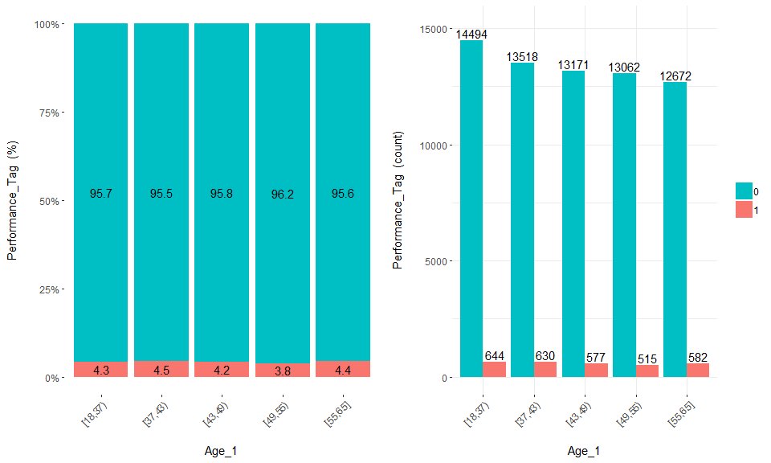

```r
# Attribute 2:  Age (numerical)
#------------------------------

#  EDA
CreditData$Age_1 <- equal_freq(var = CreditData$Age, n_bins = 5)

#  bar plot: performance ~ Income
cross_plot(CreditData,input = "Age_1", target = "Performance_Tag", auto_binning = FALSE)
```

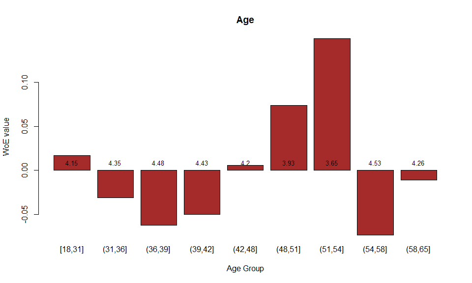

```r
#  WoE plot post coarse classing
BinAge_WoE <- WOE_fn(CreditData$Age_Group, CreditData$Performance_Tag)
bp_BinAge <- barplot(BinAge_WoE$WoE, col = "brown", names.arg = BinAge_WoE$Buckets,
                     main = "Age",
                     xlab = "Age Group",
                     ylab = "WoE value")
text(bp_BinAge, 0, round(BinAge_WoE$Bad_Rate,2) ,cex = 0.8, pos = 3) #, srt = 90
```

```r
kable(BinAge_WoE, caption = 'Customer Age ~ Good-Bad')
```

| Buckets | 0 | 1 | TotalObs | Distr_Good | Distr_Bad | Overall_Pct | Bad_Rate | WoE | IV | Efficiency |
| --- | --- | --- | --- | --- | --- | --- | --- | --- | --- | --- |
| [18,31] | 6970 | 302 | 7272 | 10.4159 | 10.2442 | 10.4086 | 4.1529 | 0.0166 | 0.0029 | 0.0859 |
| (31,36] | 7524 | 342 | 7866 | 11.2438 | 11.6011 | 11.2589 | 4.3478 | -0.0313 | 0.0112 | 0.1787 |
| (36,39] | 6825 | 320 | 7145 | 10.1992 | 10.8548 | 10.2269 | 4.4787 | -0.0623 | 0.0408 | 0.3278 |
| (39,42] | 6693 | 310 | 7003 | 10.0019 | 10.5156 | 10.0236 | 4.4267 | -0.0501 | 0.0257 | 0.2568 |
| (42,48] | 13171 | 577 | 13748 | 19.6826 | 19.5726 | 19.6780 | 4.1970 | 0.0056 | 0.0006 | 0.0550 |
| (48,51] | 6524 | 267 | 6791 | 9.7494 | 9.0570 | 9.7202 | 3.9317 | 0.0737 | 0.0510 | 0.3462 |
| (51,54] | 6538 | 248 | 6786 | 9.7703 | 8.4125 | 9.7130 | 3.6546 | 0.1496 | 0.2031 | 0.6789 |
| (54,58] | 6116 | 290 | 6406 | 9.1397 | 9.8372 | 9.1691 | 4.5270 | -0.0735 | 0.0513 | 0.3487 |
| (58,65] | 6556 | 292 | 6848 | 9.7972 | 9.9050 | 9.8018 | 4.2640 | -0.0109 | 0.0012 | 0.0539 |

The credit default rate is more or less same throughout different age bucket.

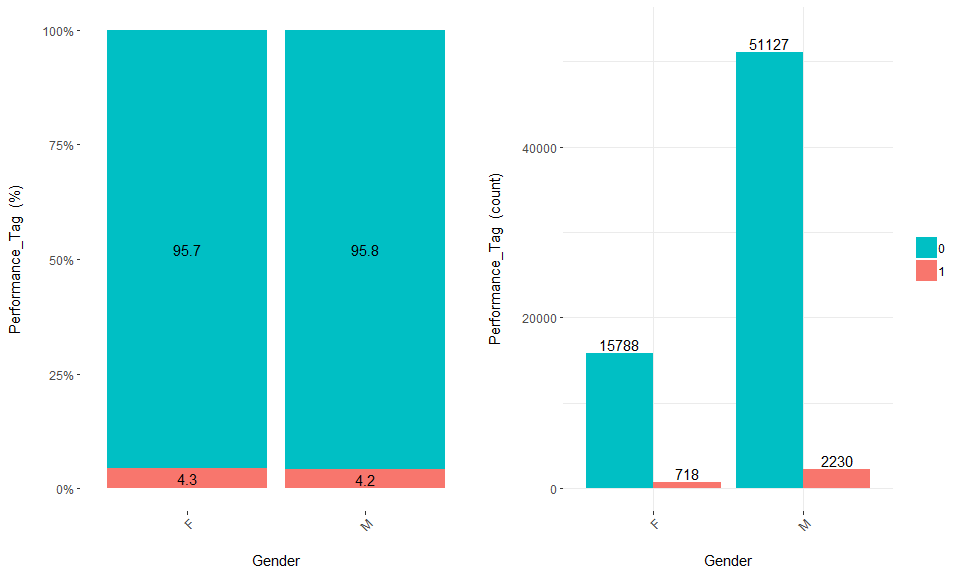

```r
# Attribute 3:  Gender (qualitative)
#-----------------------------------

# Data Quality
missing_gender <- CreditData[(CreditData$Gender == "" | is.na(CreditData$Gender)), ] # 2 observation with blank gender values

CreditData <- CreditData[!(CreditData$Gender == "" | is.na(CreditData$Gender)), ]

#  EDA
cross_plot(CreditData, input = "Gender", target = "Performance_Tag")
```

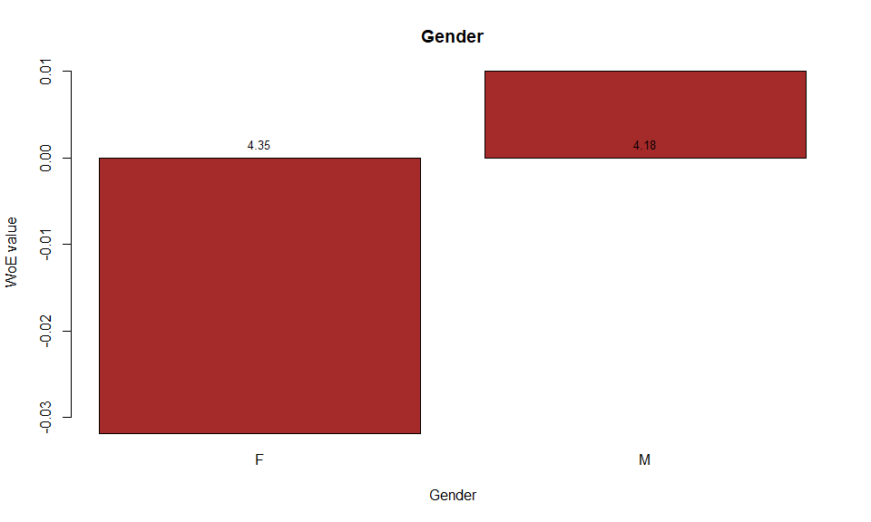

```r
#  WoE plot
Gender_WoE <- WOE_fn(CreditData$Gender, CreditData$Performance_Tag)
bp_Gender <- barplot(Gender_WoE$WoE, col = "brown", names.arg = Gender_WoE$Buckets,
                     main = "Gender",
                     xlab = "Gender",
                     ylab = "WoE value")
text(bp_Gender,0,round(Gender_WoE$Bad_Rate,2),cex = 0.8,pos = 3)
```

```r
kable(Gender_WoE, caption = 'Gender_WoE ~ Good-Bad')
```

| Buckets | 0 | 1 | TotalObs | Distr_Good | Distr_Bad | Overall_Pct | Bad_Rate | WoE | IV | Efficiency |
| --- | --- | --- | --- | --- | --- | --- | --- | --- | --- | --- |
| F | 15788 | 718 | 16506 | 23.5941 | 24.3555 | 23.6262 | 4.3499 | -0.0318 | 0.0242 | 0.3807 |
| M | 51127 | 2230 | 53357 | 76.4059 | 75.6445 | 76.3738 | 4.1794 | 0.0100 | 0.0076 | 0.3807 |

The likelihood of credit default by both the genders are almost same with males are 4.2%, while for females are 4.4%. Gender variable do not seem to be a good predictor. Similarly other categorical variable like Education, Marital Status do not seem to be good predictor.

```r
# Attribute 3:  Avgas_CC_Utilization_in_last_12_months (numerical)
#-----------------------------------------------------------------
```

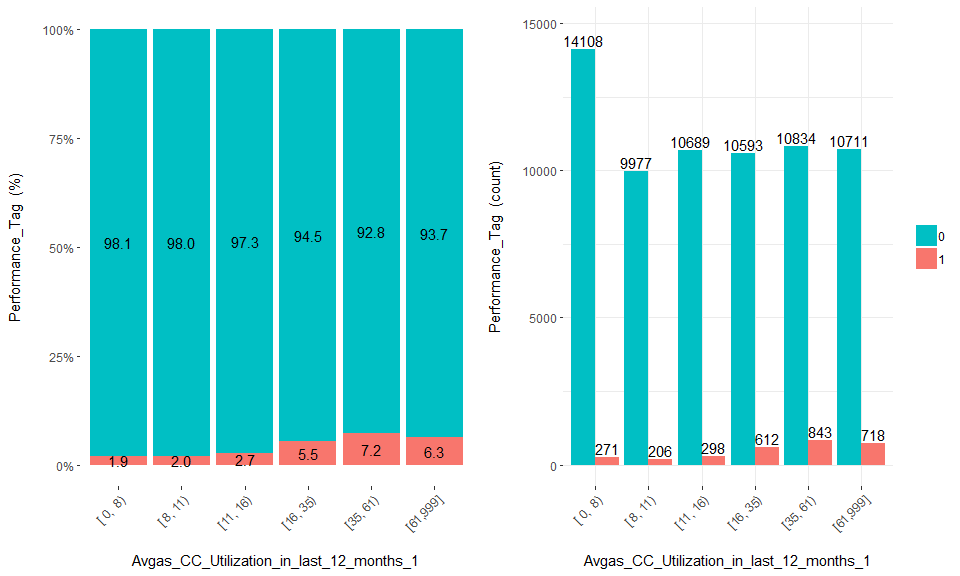

```r
# Data Quality

# We will replace missing average credit utilization with high number 999
CreditData$Avgas_CC_Utilization_in_last_12_months[which(is.na(CreditData$Avgas_CC_Utilization_in_last_12_months))] <- 999

#  EDA

CreditData$Avgas_CC_Utilization_in_last_12_months_1 <- equal_freq(var = CreditData$Avgas_CC_Utilization_in_last_12_months, n_bins = 6)

# Observation:From the plot- Average cc utilization is a strong predcitor
cross_plot(CreditData,input = "Avgas_CC_Utilization_in_last_12_months_1", target = "Performance_Tag")
```

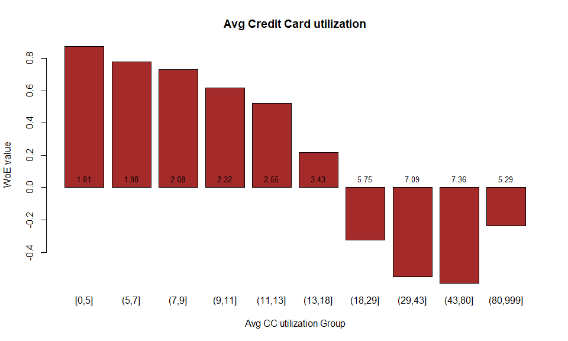

```r
#  WoE plot
AvgCCUtil_WoE <- WOE_fn(CreditData$Avg_CC_util_Group, CreditData$Performance_Tag)
bp_AvgCCUtil <- barplot(AvgCCUtil_WoE$WoE, col = "brown", names.arg = AvgCCUtil_WoE$Buckets,
                        main = "Avg Credit Card utilization",
                        xlab = "Avg CC utilization Group",
                        ylab = "WoE value")
text(bp_AvgCCUtil, 0, round(AvgCCUtil_WoE$Bad_Rate,2), cex = 0.8, pos = 3)
```

```r
knitr::kable(AvgCCUtil_WoE, caption = 'Customer Avg Credit Card utilization ~ Good-Bad')
```

| Buckets | 0 | 1 | TotalObs | Distr_Good | Distr_Bad | Overall_Pct | Bad_Rate | WoE | IV | Efficiency |
| --- | --- | --- | --- | --- | --- | --- | --- | --- | --- | --- |
| [0,5] | 7876 | 145 | 8021 | 11.7707 | 4.9186 | 11.4815 | 1.8078 | 0.8726 | 5.9791 | 3.4260 |
| (5,7] | 6232 | 126 | 6358 | 9.3137 | 4.2741 | 9.1011 | 1.9818 | 0.7789 | 3.9253 | 2.5198 |
| (7,9] | 6822 | 145 | 6967 | 10.1955 | 4.9186 | 9.9728 | 2.0812 | 0.7289 | 3.8463 | 2.6384 |
| (9,11] | 5971 | 142 | 6113 | 8.9237 | 4.8168 | 8.7504 | 2.3229 | 0.6166 | 2.5323 | 2.0535 |
| (11,13] | 4668 | 122 | 4790 | 6.9763 | 4.1384 | 6.8566 | 2.5470 | 0.5222 | 1.4820 | 1.4190 |
| (13,18] | 6283 | 223 | 6506 | 9.3899 | 7.5645 | 9.3129 | 3.4276 | 0.2162 | 0.3947 | 0.9127 |
| (18,29] | 5708 | 348 | 6056 | 8.5306 | 11.8046 | 8.6688 | 5.7464 | -0.3248 | 1.0634 | 1.6370 |
| (29,43] | 5672 | 433 | 6105 | 8.4768 | 14.6879 | 8.7389 | 7.0925 | -0.5497 | 3.4142 | 3.1056 |
| (43,80] | 11713 | 931 | 12644 | 17.5051 | 31.5807 | 18.0991 | 7.3632 | -0.5901 | 8.3060 | 7.0378 |
| (80,999] | 5967 | 333 | 6300 | 8.9177 | 11.2958 | 9.0180 | 5.2857 | -0.2364 | 0.5622 | 1.1890 |

Similarly we can measure the default rate with other variables like open trades, outstanding balance, DPD etc.

Similarly we can plot each variable and draw conclusion. Now we have a understanding of the variables which are important in predicting response.

But this way, we can only only analyse the effect of each variable separately. So, how do we analyse the combined effect of the variables? Also, how can we know which variables affect the response rate more than others?

This is what we will look into by building machine learning models.

### Model Developement

We will build few models to predict the customers who are likely to default. To estimate the parameter coefficients we will train the model on some part of the data, called as training data. We will use rest of the data to test or evaluate the model, called as test data.

For our purpose we will use 70% data to train the model and rest 30% to test the model performance.

```r
masterData_bin <- CreditData[,c(1,3:5,7:12,30:37,39:52,55)]
```

Lets check which are the important variables. To identify the important variable there are known different approaches like using varImp function from caret package, varImpPlot from randomForest package etc. For our purpose we will use Information package to derive Information value of each variable. The variable with highest information value will be most important one.

```r
# Weight of Evidence(WOE), Information Value(IV) and Efficiency
library(Information)
infoTables <- Information::create_infotables(data = masterData_bin[,-1], y = "Performance_Tag")
infoTables$Summary$IV <- round(infoTables$Summary$IV * 100,2)
```

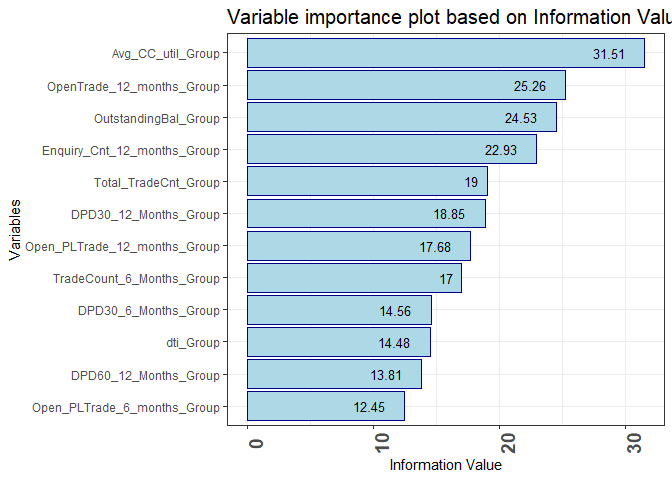

From the plot we notice that the Average credit utilization has the highest informaton value. Hence it is the most important variable followed by Open Trade, Outstanding balance etc.

Create a dataset with original values replaced with WoE values

```r
masterData_woe <- masterData_bin[,c(1,10,34:61)]
masterData_woe$Performance_Tag <- as.factor(ifelse(masterData_woe$Performance_Tag == 0, "no", "yes"))
```

Since event is just ~4% compared to non event we will use ROSE(Random Over Sampling Examples) to perform the sampling. To compare performance of different models we will build models like Logistic Regression, CART, Naive Bayes, random forest and elastic net.

```r
set.seed(1110)
intrain.idx <- createDataPartition(y = masterData_woe$Performance_Tag,p = 0.7,list = FALSE)
train.70 <- masterData_woe[intrain.idx,]
test.30 <- masterData_woe[-intrain.idx,]

data.rose <- ROSE(Performance_Tag ~., data = train.70, seed = 1)$data

fitControl <- trainControl(method = "cv",
                           number = 2,
                           classProbs = TRUE,   ## Estimate class probabilities
                           summaryFunction = twoClassSummary,
                           sampling = "rose")
```

### 1. logistic regression

```r
set.seed(42)
# glm.ROSE.1.1 <- train(Performance_Tag ~ .,
#                       data = train.70,
#                       method = "glmStepAIC",
#                       metric = "ROC",
#                       family = "binomial",
#                       trControl = fitControl)

# stepAIC has removed some variables and only the following ones remain
glm.ROSE.1.20 <- glm(Performance_Tag ~
                      Education_WoE + AvgCCutil_WoE + DPD90_6Mnths_WoE +
                      DPD30_12Mnths_WoE + OPLT_12Mnths_WoE + EnqCnt_12Mnths_WoE ,
                     family = binomial(link = "logit"), data = train.70)

summary(glm.ROSE.1.20)
vif(glm.ROSE.1.20)
```

Next, we will use the model to predict the response in the test data.

```r
pred.glmModel.rose <- as.vector(predict(glm.ROSE.1.20, newdata = test.30[,-2], type = "response"))
```

Optimal threshold cutoff as 0.034. Above this cut-off, the model will flag customers as potential defaulters

```r
glm.predicted.response <- factor(ifelse(pred.glmModel.rose >= 0.034, "yes", "no"))
conf.glm <- caret::confusionMatrix(glm.predicted.response, test.30$Performance_Tag, positive = "yes")
```

With models sensitivity at ~77% and AUC ~ 67%, we can conclude it is a fair model. Lets see if these numbers can be improved.

### 2. CART

```r
set.seed(53)
CART.ROSE.1.2 <- train(Performance_Tag ~ ., data = train.70, method = "rpart",
                       metric = "ROC", trControl = fitControl, cp = 0.0002076412)
pred.cartModel.rose <- as.vector(predict(CART.ROSE.1.2, newdata = test.30[,-2], type = "prob")[,"yes"])
```

```r
cart.predicted.response <- factor(ifelse(pred.cartModel.rose >= 0.223, "yes", "no"))
conf.cart <- caret::confusionMatrix(cart.predicted.response, test.30$Performance_Tag, positive = "yes")
```

With models sensitivity at ~73% and AUC ~ 67%, we can conclude that the CART model is not better then logit model.

### 3. Naive Bayes

```r
set.seed(42)
nb.ROSE.1.1 <- train(Performance_Tag ~ ., data = train.70, method = "nb",
                     metric = "ROC", trControl = fitControl, verbose = FALSE, tuneLength = 5)
pred.nbModel <- as.vector(predict(nb.ROSE.1.1, newdata = test.30[,-2], type = "prob")[,"yes"])
```

```r
nb.predicted.response <- factor(ifelse(pred.nbModel >= 0.154, "yes", "no"))
conf.nb <- caret::confusionMatrix(nb.predicted.response, test.30$Performance_Tag, positive = "yes")
```

With models sensitivity at ~74% and AUC ~ 66%, we can conclude that Naive Bayes model too is not better then logit model.

### 4. Random Forest

```r
set.seed(42)
# Based on tuned parameters
RF.ROSE.1.1 <- randomForest(Performance_Tag ~ ., data = data.rose,
                            ntree = 500, mtry = 4,importance = TRUE, do.trace = F)
pred.RF.rose <- predict(RF.ROSE.1.1, newdata = test.30[,-c(2)], type = "prob")[,2]
```

```r
rf.predicted.response <- factor(ifelse(pred.RF.rose >= 0.057, "yes", "no"))
conf.rf <- caret::confusionMatrix(rf.predicted.response, test.30$Performance_Tag, positive = "yes")
```

With models sensitivity at 81~% and AUC 67~ %, we can conclude that Random Forest model is better then logit, CART and Naive Bayes model.

### 5. Elastic Net

```r
set.seed(52)
eNet.ROSE.1.1 <- train(Performance_Tag ~ .,
                       data = train.70,
                       method = "glmnet",
                       metric = "ROC",
                       trControl = fitControl,
                       family = "binomial",
                       tuneLength = 5)
# check trained model performance on test data
pred.eNetModel.rose <- as.vector(predict(eNet.ROSE.1.1, newdata = test.30[,-2], type = "prob")[,"yes"])
```

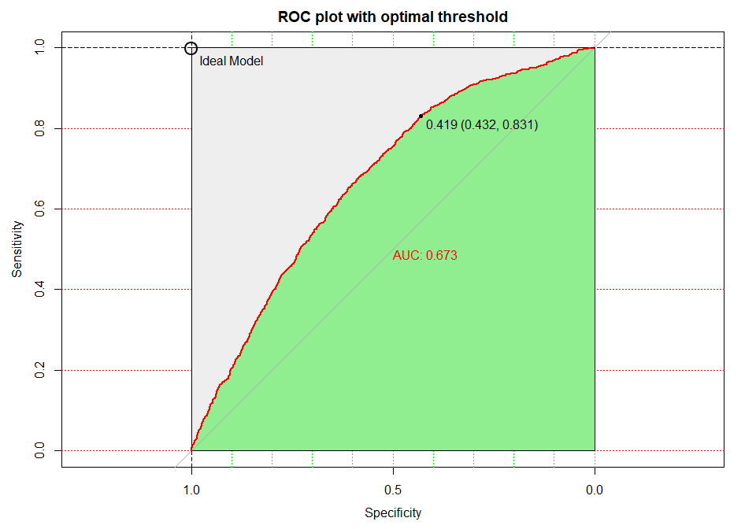

```r
# Plot the ROC
plotROC_fn(rocvalues = roc.eNetModel)
abline(v = 1, lty = 2)
abline(h = 1, lty = 2)
text(.90, .97, labels = "Ideal Model")
points(1,1, pch = "O", cex = 1.5)
```

```r
eNet.predicted.response <- factor(ifelse(pred.eNetModel.rose >= 0.419, "yes", "no"))
conf.eNet <- caret::confusionMatrix(eNet.predicted.response, test.30$Performance_Tag, positive = "yes")
```

With models sensitivity at ~83% and AUC ~ 67%, we can conclude that this model is the best among other models

```
##           Model       AUC Sensitivity
## 1           glm 0.6699781      0.7658
## 2          CART 0.6721465      0.7330
## 3   Naive Bayes 0.6640141      0.7398
## 4 Random Forest 0.6679332      0.8100
## 5   Elastic Net 0.6732972      0.8292
```

From the table above we see that ElasticNet model is best while is CART is worst model. Hence we will treat ElasticNet model as final model for further analysis.

using optimal parameters (obtained after hyper parameter training), we will train the final model

```r
final.model <- train( Performance_Tag ~ .,
                       data = train.70[,-1],
                       method = "glmnet", metric = "ROC",
                       family = "binomial",
                       tuneGrid = expand.grid(alpha = 0.325,
                                              lambda = 0.009566449),
                       trControl = fitControl_final
                     )
pred.eNetModel.rose <- as.vector(predict(final.model, newdata = test.30[,-2], type = "prob")[,"yes"])
```

```r
eNet.predicted.response <- factor(ifelse(pred.eNetModel.rose >= 0.035, "yes", "no"))
conf.eNet <- caret::confusionMatrix(eNet.predicted.response, test.30$Performance_Tag, positive = "yes")
```

Now we need to check how good is over model at classifying the defaulters from non-defaulters. For this we will plot lift cart which measures the performance of classification model.

#### Lift Chart

Lift charts compares the results one can expect from the predictive classification model compared to the result without a model. The model lift reflects the improvement in model performance (increase in true positive rate) when compared to random performance. Lift chart shows the additional response rate that would be achieved through the developed model.

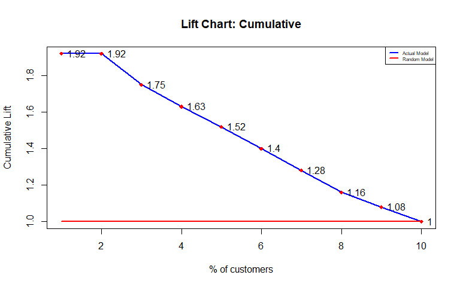

#### KS chart

Now lets plot KS chart. This chart indicates the score/probability band where separate between Goods (or Event) and Bads (or Non-event) is maximum. KS statistics measures the discriminatory power of a model.

```r
ks_stat(eNet.testSubset.30$lr.oriDefault.Status,eNet.testSubset.30$lr.predicted.prob)
```

```
## [1] 0.2692
```

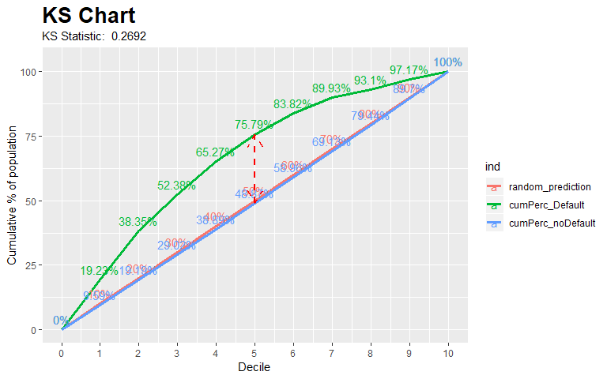

```r
# plot
ks_plot(ifelse(test.30$Performance_Tag == "no",0,1 ), pred.eNetModel.rose)
```

KS value of 26.92% is neither good nor bad. So the model identifed **~76% of potential defaulters from 50% of credit applicants**. The important variables like Average credit utilizations, Outstanding Balance, Open Trade etc should be given more weightage and scrutinized while considering credit applications.

Next step would be to build application score card using the final model to identify the cut-off score below which customers can be rejected, perform reject referencing to check how the model would have performed on rejected applications, check model performance on through the door (TTD) applications, analyze financial benefit derived from the model etc.